# Natural Events and their impact on US Population Health and Economy

Stéphane Nyombayire

June 16th, 2015

##Synopsis

The study aims to identify the most harmful weather events for the Health of USA Population and Economy. At the base of the analysis is the U.S. National Oceanic and Atmospheric Admistration’s (NOAA) storm database, that tracks characteristics of major storms and weather events in the United States, including when and where they occur, as well as estimates of any fatalities, injuries, and property damage.

Original data and documentation (quoted from the project assignment):

 [Storm Data](https://d396qusza40orc.cloudfront.net/repdata%2Fdata%2FStormData.csv.bz2) [47Mb]

There is also some documentation of the database available. Here you will find how some of the variables are constructed/defined.

 National Weather Service [Storm Data Documentation](https://d396qusza40orc.cloudfront.net/repdata%2Fpeer2_doc%2Fpd01016005curr.pdf)

 National Climatic Data Center Storm Events [FAQ](https://d396qusza40orc.cloudfront.net/repdata%2Fpeer2_doc%2FNCDC%20Storm%20Events-FAQ%20Page.pdf)

The events in the database start in the year 1950 and end in November 2011. In the earlier years of the database there are generally fewer events recorded, most likely due to a lack of good records. More recent years should be considered more complete.

## Data Processing

Loading data:

```r
stormData<-read.csv(bzfile("repdata-data-StormData.csv.bz2"), header = TRUE, sep = ",")
```

A brief summary of the data:

```r
str(stormData)
```

```
## 'data.frame':    902297 obs. of  37 variables:
##  $ STATE__   : num  1 1 1 1 1 1 1 1 1 1 ...
##  $ BGN_DATE  : Factor w/ 16335 levels "1/1/1966 0:00:00",..: 6523 6523 4242 11116 2224 2224 2260 383 3980 3980 ...
##  $ BGN_TIME  : Factor w/ 3608 levels "00:00:00 AM",..: 272 287 2705 1683 2584 3186 242 1683 3186 3186 ...
##  $ TIME_ZONE : Factor w/ 22 levels "ADT","AKS","AST",..: 7 7 7 7 7 7 7 7 7 7 ...
##  $ COUNTY    : num  97 3 57 89 43 77 9 123 125 57 ...
##  $ COUNTYNAME: Factor w/ 29601 levels "","5NM E OF MACKINAC BRIDGE TO PRESQUE ISLE LT MI",..: 13513 1873 4598 10592 4372 10094 1973 23873 24418 4598 ...
##  $ STATE     : Factor w/ 72 levels "AK","AL","AM",..: 2 2 2 2 2 2 2 2 2 2 ...
##  $ EVTYPE    : Factor w/ 985 levels "   HIGH SURF ADVISORY",..: 834 834 834 834 834 834 834 834 834 834 ...
##  $ BGN_RANGE : num  0 0 0 0 0 0 0 0 0 0 ...
##  $ BGN_AZI   : Factor w/ 35 levels "","  N"," NW",..: 1 1 1 1 1 1 1 1 1 1 ...
##  $ BGN_LOCATI: Factor w/ 54429 levels "","- 1 N Albion",..: 1 1 1 1 1 1 1 1 1 1 ...
##  $ END_DATE  : Factor w/ 6663 levels "","1/1/1993 0:00:00",..: 1 1 1 1 1 1 1 1 1 1 ...
##  $ END_TIME  : Factor w/ 3647 levels ""," 0900CST",..: 1 1 1 1 1 1 1 1 1 1 ...
##  $ COUNTY_END: num  0 0 0 0 0 0 0 0 0 0 ...
```

[output cut: 23 more lines]

The data is comprised of 902297 rows and 37 columns.

To prepare the data for analysis, let’s see if we have NAs and what is their overall impact:

`r mean(is.na(stormData))`

`## [1] 0.05229737`

The average generated by the NA cases is 0.05229737; pretty small, so we are safe ignoring these cases.

## Analysis

We are esentially trying to answer two main questions:

1. Across the United States, which types of events (as indicated in the EVTYPE variable) are most harmful with respect to population health?
2. Across the United States, which types of events have the greatest economic consequences?

To answer question 1, we need to look at all events that generated Fatalities and Injuries.

To answer question 2, we need to look at all events that generated both Property and Crop damages.

## Results: Question 1

A view of the total number of Injuries and Fatalies by Event.

```r
library(plyr)
maxFatalities <- ddply(stormData, ~EVTYPE, summarize, FatalMAx = max(FATALITIES))
maxFatalities <- maxFatalities[maxFatalities$FatalMAx > 0,]
maxFatalities <- maxFatalities[order(-maxFatalities$FatalMAx),]
maxFatalities[1:5,]
```

```
##             EVTYPE FatalMAx
## 275           HEAT      583
## 834        TORNADO      158
## 130 EXCESSIVE HEAT       99
## 142   EXTREME HEAT       57
## 278      HEAT WAVE       33
```

```r
maxInjuries <- ddply(stormData, ~EVTYPE, summarize, InjuryMAx = max(INJURIES))
maxInjuries <- maxInjuries[maxInjuries$InjuryMAx > 0,]
maxInjuries <- maxInjuries[order(-maxInjuries$InjuryMAx),]
maxInjuries[1:5,]
```

```
##                EVTYPE InjuryMAx
## 834           TORNADO      1700
## 427         ICE STORM      1568
## 170             FLOOD       800
## 411 HURRICANE/TYPHOON       780
## 130    EXCESSIVE HEAT       519
```

Comparative charts:

`r library(portfolio)`

`r par(mfrow = c(1,2)) par(mar = c(15, 4, 4, 2)) map.market(id = stormData$REFNUM, area = stormData$FATALITIES, group = stormData$EVTYPE, color = stormData$FATALITIES, main = "National Weather Service: Fatalities" )`

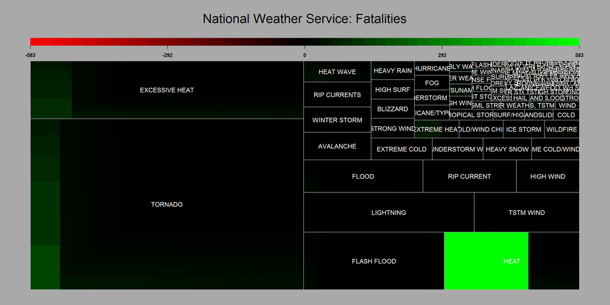

`r map.market(id = stormData$REFNUM, area = stormData$INJURIES, group = stormData$EVTYPE, color = stormData$INJURIES, main = "National Weather Service: Injuries" )`

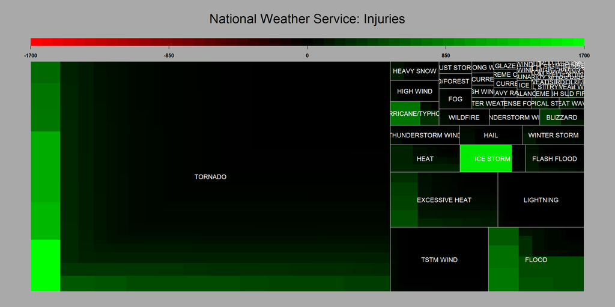

The Top 3 most harmful natural events for US inhabitants are (area of the tiles):

- for fatalities: Tornado, Excessive Heat and Flash Flood. Important to note that Heat had the most casuality for a single event with 583 fatalities (Visually this is how green the tile is). In the top 5 most fatal events, Heat related events occupy 4 places
- for injuries: Tornado, Tstm Wind and Flood. In the top 5 most injury prone single events, ICE Storm are second behind Tornadoes.

It is also worthy to note that the scale of injuries is of an order of magnitude higher than the fatalities scale (Tornado: 91346 injuries vs. 5633 fatalities)

## Results: Question 2

Before we can proceed with the identification of top most damaging events, we need to realign the value of damages, as they are expressed in many different ways.

The columns of importance are:

- for property damage: PROPDMG, PROPDMGEXP
- for crop damage: CROPDMG, CROPDMGEXP

To align and measure all damages correctly, we’ll create 2 new variables that will contain the correct values.

```r
## values of PROPDMGEXP: - ? + 0 1 2 3 4 5 6 7 8 B h H K m M

##initializing the new variable with 0 will take care of the -, ?, and + values that we do not know how to deal with; and of 0 value
stormData$PROPDMGVAL <- 0

stormData$PROPDMGVAL[stormData$PROPDMGEXP == "B"] <- stormData$PROPDMG[stormData$PROPDMGEXP == "B"] * 10^9
stormData$PROPDMGVAL[stormData$PROPDMGEXP == "m" | stormData$PROPDMGEXP == "M"] <- stormData$PROPDMG[stormData$PROPDMGEXP == "m" | stormData$PROPDMGEXP == "M"] * 10^6
stormData$PROPDMGVAL[stormData$PROPDMGEXP == "K"] <- stormData$PROPDMG[stormData$PROPDMGEXP == "K"] * 10^3
stormData$PROPDMGVAL[stormData$PROPDMGEXP == "h" | stormData$PROPDMGEXP == "H"] <- stormData$PROPDMG[stormData$PROPDMGEXP == "h" | stormData$PROPDMGEXP == "H"] * 10^2

stormData$PROPDMGVAL[stormData$PROPDMGEXP == "1"] <- stormData$PROPDMG[stormData$PROPDMGEXP == "1"] * 10^1
stormData$PROPDMGVAL[stormData$PROPDMGEXP == "2"] <- stormData$PROPDMG[stormData$PROPDMGEXP == "2"] * 10^2
stormData$PROPDMGVAL[stormData$PROPDMGEXP == "3"] <- stormData$PROPDMG[stormData$PROPDMGEXP == "3"] * 10^3
stormData$PROPDMGVAL[stormData$PROPDMGEXP == "4"] <- stormData$PROPDMG[stormData$PROPDMGEXP == "4"] * 10^4
stormData$PROPDMGVAL[stormData$PROPDMGEXP == "5"] <- stormData$PROPDMG[stormData$PROPDMGEXP == "5"] * 10^5
stormData$PROPDMGVAL[stormData$PROPDMGEXP == "6"] <- stormData$PROPDMG[stormData$PROPDMGEXP == "6"] * 10^6
stormData$PROPDMGVAL[stormData$PROPDMGEXP == "7"] <- stormData$PROPDMG[stormData$PROPDMGEXP == "7"] * 10^7
stormData$PROPDMGVAL[stormData$PROPDMGEXP == "8"] <- stormData$PROPDMG[stormData$PROPDMGEXP == "8"] * 10^8

##do the same for CROPDMGEXP's values: ? 0 2 B k K m M

stormData$CROPDMGVAL <- 0
stormData$CROPDMGVAL[stormData$CROPDMGEXP == "B"] <- stormData$CROPDMG[stormData$CROPDMGEXP == "B"] * 10^9
stormData$CROPDMGVAL[stormData$CROPDMGEXP == "m"| stormData$CROPDMGEXP == "M"] <- stormData$CROPDMG[stormData$CROPDMGEXP == "m"| stormData$CROPDMGEXP == "M"] * 10^6
stormData$CROPDMGVAL[stormData$CROPDMGEXP == "k" | stormData$CROPDMGEXP == "K"] <- stormData$CROPDMG[stormData$CROPDMGEXP == "k" | stormData$CROPDMGEXP == "K"] * 10^3
stormData$CROPDMGVAL[stormData$CROPDMGEXP == "2"] <- stormData$CROPDMG[stormData$CROPDMGEXP == "2"] * 10^2
```

We’re going to group the data by event type, calculating the cumulative value of damages per event.

```r
library(plyr)
maxPropDmg <- ddply(stormData, ~EVTYPE, summarize, PropDmgMAx = max(PROPDMGVAL))
maxPropDmg <- maxPropDmg[maxPropDmg$PropDmgMAx > 0,]
maxPropDmg <- maxPropDmg[order(-maxPropDmg$PropDmgMAx),]
maxPropDmg[1:5,]
```

```
##                EVTYPE PropDmgMAx
## 170             FLOOD  1.150e+11
## 670       STORM SURGE  3.130e+10
## 411 HURRICANE/TYPHOON  1.693e+10
## 848    TROPICAL STORM  5.150e+09
## 590       RIVER FLOOD  5.000e+09
```

```r
maxCropDmg <- ddply(stormData, ~EVTYPE, summarize, CropDmgMAx = max(CROPDMGVAL))
maxCropDmg <- maxCropDmg[maxCropDmg$CropDmgMAx > 0,]
maxCropDmg <- maxCropDmg[order(-maxCropDmg$CropDmgMAx),]
maxCropDmg[1:5,]
```

```
##                EVTYPE CropDmgMAx
## 427         ICE STORM   5.00e+09
## 590       RIVER FLOOD   5.00e+09
## 411 HURRICANE/TYPHOON   1.51e+09
## 95            DROUGHT   1.00e+09
## 140      EXTREME COLD   5.96e+08
```

```r
propDmg <-  ddply(stormData, ~EVTYPE, summarize, totalPropDmg = sum(PROPDMGVAL))
propDmg <- propDmg[order(-propDmg$totalPropDmg), ]
propDmgTop20<-propDmg[1:20, ]

cropDmg <-  ddply(stormData, ~EVTYPE, summarize, totalCropDmg = sum(CROPDMGVAL))
cropDmg <- cropDmg[order(-cropDmg$totalCropDmg), ]
cropDmgTop20<-cropDmg[1:20, ]
```

A visual representation of the two sets of most damaging events:

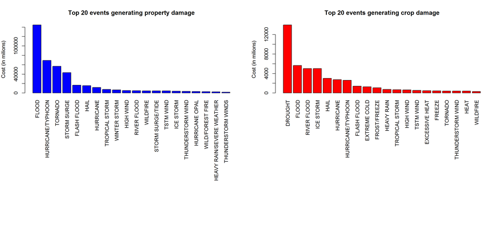

```r
par(mfrow = c(1,2))
par(mar = c(25, 4, 4, 2))
barplot(propDmgTop20$totalPropDmg/10^6, names.arg = propDmgTop20$EVTYPE, col = "blue", las = 3, main = "Top 20 events generating property damage", ylab = "Cost (in milions)")
barplot(cropDmgTop20$totalCropDmg/10^6, names.arg = cropDmgTop20$EVTYPE, col = "red", las = 3, main = "Top 20 events generating crop damage", ylab = "Cost (in milions)")
```

as well as a look at the top of the two data sets

```r
head(propDmgTop20)
```

```
##                EVTYPE totalPropDmg
## 170             FLOOD 144657709800
## 411 HURRICANE/TYPHOON  69305840000
## 834           TORNADO  56947380480
## 670       STORM SURGE  43323536000
## 153       FLASH FLOOD  16822673510
## 244              HAIL  15735267220
```

```r
head(cropDmgTop20)
```

```
##          EVTYPE totalCropDmg
## 95      DROUGHT  13972566000
## 170       FLOOD   5661968450
## 590 RIVER FLOOD   5029459000
## 427   ICE STORM   5022113500
## 244        HAIL   3025954450
## 402   HURRICANE   2741910000
```

shows that the Top 3 most harmful events for the US Economy are:

- property damaging: Flood, Hurricane / Typhoon, Tornado. Flood the most expensive single event impacting property
- crop damaging:Drought, Flood and River Flood. Important to call out the most expensive single event impacting crops are ICE Storm & River Flood

Looking at the data sets, we can easily see that Tornadoes are in the Top 3 for both human life fatalities / injuries and property damages. Another top event is Flood, which is one of the top reason for damages in both property and crop damages, as well as human fatalities / injuries.